# Problem 1

Suppose $(x_{1}, y_{1}), (x_{2}, y_{2}), \cdots, (x_{n}, y_{n}) \in \mathbb{R} \times \{0,1\}$. Set \begin{equation*} \begin{split} \sigma(t) &= \frac{1}{1 + e^{-t}} \\ p_{i}(a, b) &= \sigma(a + b x_{i})^{y_{i}} (1 - \sigma(a + b x_{i}))^{1 -y_{i}} \\ l_{i}(a, b) &= -\log p_{i}(a, b) \\ &= -y_{i} \log (\sigma(a + b x_{i})) - (1 - y_{i}) \log((1 - \sigma(a + b x_{i}))) \\ l(a, b) &= \sum_{i=1}^{n} l_{i}(a , b) \end{split} \end{equation*}

## (a)

\textbf{Proof:} \begin{equation*} \begin{split} \sigma(x) & = \frac{1}{1 + e^{-x}} = (1 + e^{-x})^{-1} \\ \sigma '(x) &= (-1) (1 + e^{-x})^{-2} (0 + e^{-x}(-1)) \\ &=\frac{e^{-x}}{(1 + e^{-x})^{2}} \\ \sigma(x) (1 - \sigma(x)) &= \frac{1}{1+e^{-x}} \left( 1 - \frac{1}{1+e^{-x}}\right) \\& = \frac{1}{1+e^{-x}} \left( \frac{1+e^{-x} - 1}{1+e^{-x}}\right) \\& = \frac{e^{-x}}{(1 + e^{-x})^{2}} \end{split} \end{equation*}

Therefore, we proved that $\sigma '(x) = \sigma(x) (1 - \sigma(x))$.

## (b)

To get the $\bigtriangledown l_{i}(a, b)$, we derive $\frac{\partial l_{i}(a,b)}{\partial a}$ and $\frac{\partial l_{i}(a,b)}{\partial b}$ respectively.

\begin{equation*} \begin{split} \frac{\partial l_{i}(a,b)}{\partial a} &= -y_{i} \frac{\sigma'(a + bx_{i})}{\sigma(a + bx_{i})}\frac{\partial (a + bx_{i})}{\partial a} - (1 - y_{i})\frac{-\sigma'(a + bx_{i})}{1 - \sigma(a + bx_{i})}\frac{\partial (a + bx_{i})}{\partial a} \\& = -y_{i}\frac{\sigma(a + bx_{i})(1 - \sigma(a + bx_{i}))}{\sigma(a + bx_{i})} + (1 - y_{i})\frac{\sigma(a + bx_{i})(1 - \sigma(a + bx_{i}))}{1 - \sigma(a + bx_{i})} \\& = -y_{i}(1 - \sigma(a + bx_{i})) + (1 - y_{i}) \sigma(a + bx_{i}) \\& = \sigma(a + bx_{i}) - y_{i} \end{split} \end{equation*}

\begin{equation*} \begin{split} \frac{\partial l_{i}(a,b)}{\partial b} &= -y_{i} \frac{\sigma'(a + bx_{i})}{\sigma(a + bx_{i})}\frac{\partial (a + bx_{i})}{\partial b} - (1 - y_{i})\frac{-\sigma'(a + bx_{i})}{1 - \sigma(a + bx_{i})}\frac{\partial (a + bx_{i})}{\partial b} \\& = -y_{i}\frac{\sigma(a + bx_{i})(1 - \sigma(a + bx_{i}))}{\sigma(a + bx_{i})}x_{i} + (1 - y_{i})\frac{\sigma(a + bx_{i})(1 - \sigma(a + bx_{i}))}{1 - \sigma(a + bx_{i})}x_{i} \\& = -y_{i}(1 - \sigma(a + bx_{i}))x_{i} + (1 - y_{i}) \sigma(a + bx_{i})x_{i} \\& = [\sigma(a + bx_{i}) - y_{i}]x_{i} \end{split} \end{equation*}

Then, \begin{equation*} \begin{split} \bigtriangledown l_{i}(a, b) &= \begin{pmatrix} \frac{\partial l_{i}(a,b)}{\partial a}\\ \frac{\partial l_{i}(a,b)}{\partial b} \end{pmatrix} \\& = \begin{pmatrix} \sigma(a + bx_{i}) - y_{i}\\ [\sigma(a + bx_{i}) - y_{i}]x_{i} \end{pmatrix} \\& = (\sigma(a + bx_{i}) - y_{i}) \begin{pmatrix} 1\\ x_{i} \end{pmatrix} \end{split} \end{equation*}

And \begin{equation*} \begin{split} \bigtriangledown ^{2} l_{i}(a, b) &= \begin{pmatrix} \frac{\partial ^{2} l_{i}(a,b)}{\partial a^{2}} & \frac{\partial ^{2} l_{i}(a,b)}{\partial a \partial b}\\ \frac{\partial ^{2} l_{i}(a,b)}{\partial b \partial a} & \frac{\partial ^{2} l_{i}(a,b)}{\partial b^{2}} \end{pmatrix} \\& = \begin{pmatrix} \sigma'(a + bx_{i}) & \sigma'(a + bx_{i}) x_{i}\\ \sigma'(a + bx_{i}) x_{i} & \sigma'(a + bx_{i}) x_{i}^{2} \end{pmatrix} \\& = \sigma'(a + bx_{i}) \begin{pmatrix} 1 & x_{i}\\ x_{i} & x_{i}^{2} \end{pmatrix} \end{split} \end{equation*}

Now we are going to prove $\bigtriangledown ^{2} g$ is positive-semidefinite but not positive-definite, making $g(a, b)$ convex but not strictly convex. First, show the following proposition.

\textbf{[Proposition 1]}

Assume that $g : \mathbb{R}^{2} \mapsto \mathbb{R}$ is differentiable, for every $\mathbf{x}$ and $\mathbf{y}$, if the inequality $$g(\mathbf{y}) \geqslant g(\mathbf{x}) +\bigtriangledown ^{2} g(\mathbf{x}) (\mathbf{y} - \mathbf{x})$$ is satisfied, then $g$ is convex.

\textbf{Proof}:

Let $\mathbf{w}$, $\mathbf{z} \in \mathbb{R}^{2}$, and $0 \leqslant \lambda \leqslant 1$. Denote $\mathbf{x} := \lambda \mathbf{w} + (1 - \lambda)\mathbf{z}$. Then the inequality implies \begin{equation} \label{inequality} g(\mathbf{w}) \geqslant g(\mathbf{x}) +\bigtriangledown ^{2} g(\mathbf{x}) (\mathbf{w} - \mathbf{x})\\ g(\mathbf{z}) \geqslant g(\mathbf{x}) +\bigtriangledown ^{2} g(\mathbf{x}) (\mathbf{z} - \mathbf{x}) \end{equation}

Note that \begin{equation*} \mathbf{w} - \mathbf{x} = (1 - \lambda) (\mathbf{w} - \mathbf{z})\\ \mathbf{z} - \mathbf{x} = \lambda (\mathbf{z} - \mathbf{w}) \end{equation*}

We multiply the first line in \ref{inequality} with $\lambda$ and the second line with $1 - \lambda$, and then add the two inequality in \ref{inequality} together, we obtain \begin{equation*} \begin{split} \lambda g(\mathbf{w}) + (1 - \lambda) g(\mathbf{z}) &\geqslant g (\mathbf{x}) + \lambda \bigtriangledown^{\top} g(\mathbf{x})(1 - \lambda)(\mathbf{w} - \mathbf{z}) + \lambda \bigtriangledown^{\top} g(\mathbf{x})(1 - \lambda)(\mathbf{z} - \mathbf{w}) \\ &= g(\lambda \mathbf{w} + (1 - \lambda)\mathbf{z}) \end{split} \end{equation*} Since $\mathbf{w}$ and $\mathbf{z}$ are arbitrary, this proves $g$ is a convex function.

$\square$

Then deduce $\bigtriangledown ^{2} g$ is positive-semidefinite but not positive-definite, making $g(a, b)$ convex but not strictly convex.

\textbf{Proof}:

Now assume the Hessian $\bigtriangledown ^{2} g$ is positive-semidefinite for all $\mathbf{x} \in \mathbb{R}^{2}$. Then $\forall \mathbf{x}$ and $\mathbf{y} \in \mathbb{R}^{2}$, the Taylor's theorem implies that \begin{equation*} g(\mathbf{y}) = g(\mathbf{x}) + \bigtriangledown ^{\top} g(\mathbf{x})(\mathbf{y} - \mathbf{x}) +\frac{1}{2}(\mathbf{y} - \mathbf{x})^{\top}\bigtriangledown ^{2} g(t\mathbf{x} + (1-t)\mathbf{y}) (\mathbf{y} - \mathbf{x}) \end{equation*} for some $0 \leqslant t \leqslant 1$. Since $\bigtriangledown ^{2} g$ is everywhere positive semi-definite, the quadratic term in this equation is always non-negative. Thus we can estimate \begin{equation*} g(\mathbf{y}) \geqslant g(\mathbf{x}) + \bigtriangledown ^{\top} g(\mathbf{x})(\mathbf{y} - \mathbf{x}) \end{equation*} By \textbf{proposition 1}, $g$ is convex but not strictly convex.

$\square$

## (c)

From (b), we have \begin{equation*} \bigtriangledown ^{2} l_{i}(a, b) = \begin{pmatrix} \sigma'(a + bx_{i}) & \sigma'(a + bx_{i}) x_{i}\\ \sigma'(a + bx_{i}) x_{i} & \sigma'(a + bx_{i}) x_{i}^{2} \end{pmatrix} \end{equation*}

Based on the definition of null space, let $\bigtriangledown ^{2} l_{i}(a, b) (m_{i}, n_{i})^{\top} = (0, 0)^{\top}$, we have

\begin{equation*} \left\{\begin{matrix} \sigma'(a + bx_{i}) m_{i} + \sigma'(a + bx_{i}) x_{i} n_{i} = 0 & (1)\\ \sigma'(a + bx_{i}) x_{i} m_{i} + \sigma'(a + bx_{i}) x_{i}^{2} n_{i} = 0 & (2) \end{matrix}\right. \end{equation*}

From (1), we have $m_{i} = -x_{i}n_{i}$. Let $n_{i} = 1$, then $m_{i} = -x_{i}$. Normalize $n$ and $m$, we have \begin{equation*} \begin{split} n_{i0} &= \frac{1}{\sqrt{x_{i}^{2}+1}} \\ m_{i0}& = -\frac{x_{i}}{\sqrt{x_{i}^{2}+1}} \end{split} \end{equation*}

Therefore, a basis of the null space $N(\bigtriangledown ^{2} l_{i}(a, b))$ is \begin{equation*} \begin{pmatrix} -\frac{x_{i}}{\sqrt{x_{i}^{2}+1}}\\ \frac{1}{\sqrt{x_{i}^{2}+1}} \end{pmatrix} \end{equation*}

Moreover, we can write the null space as \begin{equation*} N(\bigtriangledown ^{2} l_{i}(a, b)) = \left\{ (m_{i}, n_{i})^{\top} : m_{i} = -\frac{x_{i}}{\sqrt{x_{i}^{2}+1}} t_{i}, n_{i} = \frac{1}{\sqrt{x_{i}^{2}+1}}t_{i}, \text{$t_{i}$ is any value and $t_{i} \in \mathbb{R} $ } \right\} \end{equation*}

## (d)

Note that $N(\bigtriangledown ^{2} l_{i}(a, b)) = \left\{ (m_{i}, n_{i})^{\top} : m_{i} = -\frac{x_{i}}{\sqrt{x_{i}^{2}+1}} t_{i}, n_{i} = \frac{1}{\sqrt{x_{i}^{2}+1}}t_{i}, t_{i} \in \mathbb{R} \right\}$, then,

\begin{equation*} \begin{split} \bigcap_{i=1}^{n} N(\bigtriangledown ^{2} l_{i}(a, b)) &= \left \{ \left \{ \begin{pmatrix} -\frac{x_{1}}{\sqrt{x_{1}^{2}+1}}t_{1}\\ \frac{1}{\sqrt{x_{1}^{2}+1}}t_{1} \end{pmatrix} \right\} \bigcap \left \{ \begin{pmatrix} -\frac{x_{2}}{\sqrt{x_{2}^{2}+1}}t_{2}\\ \frac{1}{\sqrt{x_{2}^{2}+1}}t_{2} \end{pmatrix} \right\} \bigcap \cdots \bigcap \left \{ \begin{pmatrix} -\frac{x_{n}}{\sqrt{x_{n}^{2}+1}}t_{n}\\ \frac{1}{\sqrt{x_{n}^{2}+1}}t_{n} \end{pmatrix} \right\}\right\} \\& = \left \{ \begin{pmatrix} 0\\ 0 \end{pmatrix}\right \} \end{split} \end{equation*}

Since when $x_{i} \neq x_{j}$, then $ \begin{pmatrix} -\frac{x_{i}}{\sqrt{x_{i}^{2}+1}}\\ \frac{1}{\sqrt{x_{i}^{2}+1}} \end{pmatrix} \neq \begin{pmatrix} -\frac{x_{j}}{\sqrt{x_{j}^{2}+1}}\\ \frac{1}{\sqrt{x_{j}^{2}+1}} \end{pmatrix}$. Now we are going to prove that $ \begin{pmatrix} -\frac{x_{i}}{\sqrt{x_{i}^{2}+1}}t_{i}\\ \frac{1}{\sqrt{x_{i}^{2}+1}}t_{i} \end{pmatrix} = \begin{pmatrix} -\frac{x_{j}}{\sqrt{x_{j}^{2}+1}}t_{j}\\ \frac{1}{\sqrt{x_{j}^{2}+1}}t_{j} \end{pmatrix}$ only when they are $0$ vector.

If $-\frac{x_{i}}{\sqrt{x_{i}^{2}+1}}t_{i} = -\frac{x_{j}}{\sqrt{x_{j}^{2}+1}}t_{j} \neq 0$, then we have $t_{i} = \frac{x_{j}}{\sqrt{x_{j}^{2}+1}} \frac{\sqrt{x_{i}^{2}+1}}{x_{i}}t_{j}$. Plug this $t_{i}$ into $\frac{1}{\sqrt{x_{i}^{2}+1}}t_{i}$, we have $\frac{1}{\sqrt{x_{i}^{2}+1}}t_{i} = \frac{1}{\sqrt{x_{i}^{2}+1}}\frac{x_{j}}{\sqrt{x_{j}^{2}+1}} \frac{\sqrt{x_{i}^{2}+1}}{x_{i}}t_{j} = \frac{x_{j}}{x_{i}\sqrt{x_{j}^{2}+1}}t_{j} \neq \frac{1}{\sqrt{x_{j}^{2}+1}}t_{j}$. Therefore, we can not find $t_{i}$ and $t_{j}$ such that $ \begin{pmatrix} -\frac{x_{i}}{\sqrt{x_{i}^{2}+1}}t_{i}\\ \frac{1}{\sqrt{x_{i}^{2}+1}}t_{i} \end{pmatrix} = \begin{pmatrix} -\frac{x_{j}}{\sqrt{x_{j}^{2}+1}}t_{j}\\ \frac{1}{\sqrt{x_{j}^{2}+1}}t_{j} \end{pmatrix} \neq 0$.

## (e)

From (b) we have \begin{equation*} \bigtriangledown ^{2} l_{i}(a, b) = \begin{pmatrix} \sigma'(a + bx_{i}) & \sigma'(a + bx_{i}) x_{i}\\ \sigma'(a + bx_{i}) x_{i} & \sigma'(a + bx_{i}) x_{i}^{2} \end{pmatrix} \end{equation*}

Then by the result in (b), $l(a,b)$ is a convex function.

## (f)

From (e), for $x_{i} \neq x_{j}$, we have $l(a, b)$ is a convex function. Suppose there are two optimal solutions $\mathbf{\omega} = (a_{1}, b_{1})^{\top}$, $\mathbf{\nu} = (a_{2}, b_{2})^{\top} \in \mathbb{R^{2}}$ s.t.

\begin{equation} \label{l_function} l(\mathbf{\omega}) = l(\mathbf{\nu}) \leqslant l(\mathbf{z}), \ \forall \mathbf{z} \in \mathbb{R}^{2} \end{equation} Let $\mathbf{z} = \frac{\omega + \nu}{2}$, by convexity of function $l(a, b)$, we have \begin{equation} \label{l_inequality} \begin{split} l(\mathbf{z}) = l(\frac{\omega + \nu}{2}) &= l(\frac{1}{2}\omega + \frac{1}{2} \nu) \\& \leqslant \frac{1}{2}l(\omega) + \frac{1}{2}l( \nu) \\& \leqslant \frac{1}{2}l(\omega) + \frac{1}{2}l(\omega) \\& = l(\omega) \end{split} \end{equation}

But this contradicts with \ref{l_function}. Therefore, the minimizer of $l(a, b)$ is unique, which means the maximize likelihood estimates $\hat{a}$, $\hat{b}$ of function $-l(a, b)$ is unique. Note that the second inequality above is because the $\nu$ is arbitrary so we can take $\nu = \omega$.

# Problem 2

## （a）

\textbf{Proof}:

We have \begin{equation*} \begin{split} \\ \sigma '(x) &= (-1) (1 + e^{-x})^{-2} (0 + e^{-x}(-1)) \\ &=\frac{e^{-x}}{(1 + e^{-x})^{2}} \\ & = \sigma(x) (1 - \sigma(x)) \\& > 0 \end{split} \end{equation*} Then $\sigma(x)$ is increasing. Take $x$ approximate to $-\infty$ and $\infty$, we can get the range of \begin{equation*} \sigma(x) = \frac{1}{1 + e^{-x}} \in (0,1) \end{equation*}

Secondly, $\log(x)$ is also increasing in $(0, \infty)$. Specifically, $\log(1) = 0$. Therefore, the range of $\log(x)$ in $(0,1)$ is $(-\infty, 0)$.

Since \begin{equation*} \begin{split} l_{i}(a, b) &= -\log p_{i}(a, b) \\ &= -y_{i} \log (\sigma(a + b x_{i})) - (1 - y_{i}) \log(1 - \sigma(a + b x_{i})) \end{split} \end{equation*}

For $y_{i} = 0$, we have $l_{i}(a, b) = - \log(1 - \sigma(a + b x_{i})) \in (0, \infty)$, since $1 - \sigma(a + b x_{i}) \in (0,1)$.

For $y_{i} = 1$, we have $l_{i}(a, b) = - \log (\sigma(a + b x_{i})) \in (0, \infty)$, since $\sigma(a + b x_{i}) \in (0,1)$.

From the above, $l_{i}(a, b) > 0$ for all $(a, b) \in \mathbb{R}^{2}$.

## (b)

We have \begin{equation*} \begin{split} l_{i}(t v_{1}, t v_{2}) = -y_{i} \log (\sigma(t v_{1} + t v_{2} x_{i})) - (1 - y_{i}) \log(1 - \sigma(t v_{1} + t v_{2} x_{i})) \end{split} \end{equation*}

When $y_{i} = 0$, $l_{i}(t v_{1}, t v_{2}) = - \log(1 - \sigma(t v_{1} + t v_{2} x_{i}))$, then \begin{equation*} \begin{split} H_{i} &= \{(v_{1}, v_{2})^{\top} \in \mathbb{R}^{2} : \lim_{t \to \infty} l_{i}(t v_{1}, t v_{2}) = \infty \} \\& = \{(v_{1}, v_{2})^{\top} \in \mathbb{R}^{2} : \lim_{t \to \infty} [-\log(1 - \sigma(t v_{1} + t v_{2}x_{i}))] = \infty \} \\& = \{(v_{1}, v_{2})^{\top} \in \mathbb{R}^{2} : \lim_{t \to \infty} (1 - \sigma(t v_{1} + t v_{2}x_{i})) = 0 \} \\& = \{(v_{1}, v_{2})^{\top} \in \mathbb{R}^{2} : \lim_{t \to \infty} (\sigma(t v_{1} + t v_{2}x_{i})) = 1 \} \\& = \{(v_{1}, v_{2})^{\top} \in \mathbb{R}^{2} : \lim_{t \to \infty} t (v_{1} + v_{2}x_{i}) = \infty \} \\& = \{(v_{1}, v_{2})^{\top} \in \mathbb{R}^{2} : v_{1} + v_{2}x_{i} > 0 \} \\& = \{(v_{1}, v_{2})^{\top} \in \mathbb{R}^{2} : (v_{1}, v_{2}) \cdot (1, x_{i})^{\top} > 0 \} \\& = H(w_{i}) \end{split} \end{equation*} where $w_{i} = (1, x_{i})^{\top}$.

When $y_{i} = 1$, $l_{i}(t v_{1}, t v_{2}) = - \log(\sigma(t v_{1} + t v_{2} x_{i}))$, then \begin{equation*} \begin{split} H_{i} &= \{(v_{1}, v_{2})^{\top} \in \mathbb{R}^{2} : \lim_{t \to \infty} l_{i}(t v_{1}, t v_{2}) = \infty \} \\& = \{(v_{1}, v_{2})^{\top} \in \mathbb{R}^{2} : \lim_{t \to \infty} [-\log(\sigma(t v_{1} + t v_{2}x_{i}))] = \infty \} \\& = \{(v_{1}, v_{2})^{\top} \in \mathbb{R}^{2} : \lim_{t \to \infty} \sigma(t v_{1} + t v_{2}x_{i}) = 0 \} \\& = \{(v_{1}, v_{2})^{\top} \in \mathbb{R}^{2} : \lim_{t \to \infty} t (v_{1} + v_{2}x_{i}) = - \infty \} \\& = \{(v_{1}, v_{2})^{\top} \in \mathbb{R}^{2} : v_{1} + v_{2}x_{i} < 0 \} \\& = \{(v_{1}, v_{2})^{\top} \in \mathbb{R}^{2} : - v_{1} - v_{2}x_{i} > 0 \} \\& = \{(v_{1}, v_{2})^{\top} \in \mathbb{R}^{2} : (v_{1}, v_{2}) \cdot (-1, -x_{i})^{\top} > 0 \} \\& = H(w_{i}) \end{split} \end{equation*} where $w_{i} = (-1, -x_{i})^{\top}$.

In conclusion, $w_{i} = (-1)^{y_{i}}\cdot(1, x_{i})^{\top}$.

# Problem 3

## (a)

\begin{equation*} \begin{split} E(S^{2}) &= E\left(\frac{(m-1)S_{X}^{2}+(n-1)S_{Y}^{2}}{m+n-2} \right) \\& = \left(\frac{(m-1)E(S_{X}^{2})+(n-1)E(S_{Y}^{2})}{m+n-2} \right) \\& = \left(\frac{(m-1)\sigma^{2}+(n-1)\sigma^{2}}{m+n-2} \right) \\& = \sigma^{2} \end{split} \end{equation*}

Therefore, the pooled variance estimator $S^{2}$ is an unbiased estimator of $\sigma^{2}$.

# Problem 4

## (a)

```python
from sklearn.linear_model import LogisticRegression
from sklearn.model_selection import train_test_split
from sklearn.metrics import confusion_matrix
from sklearn.metrics import classification_report
from matplotlib import pyplot as plt
import pandas as pd
import numpy as np
```

```python
# input data
data = pd.read_csv("dataset_1.csv")
dataset = pd.DataFrame(data)

# rename the columns of dataset
dataset.columns = ['feature_1', 'feature_2','label']

#select subdataset by label 0 or 1
data1 = dataset[dataset['label'] == 1]
data0 = dataset[dataset['label'] == 0]
```

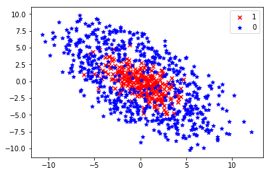

```python
#scatter plot
p1 = plt.scatter(data1['feature_1'], data1['feature_2'], marker = 'x', color = 'r', label = '1', s = 30)
p2 = plt.scatter(data0['feature_1'], data0['feature_2'], marker = '*', color = 'b', label = '0', s = 30)
plt.legend(loc = 'upper right')
```

## (b)

Fit the data to a logistic regression model and plot the decision boundary.

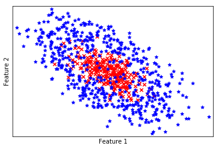

```python
X = dataset[['feature_1','feature_2']]
Y = dataset.label

X_train, X_test, y_train, y_test = train_test_split(X, Y, test_size = .1, random_state=np.random.randint(10e5))

# Use Logistic Regression model and fit the data
logreg = LogisticRegression(solver='lbfgs', multi_class='multinomial')
logreg.fit(X_train, y_train)

# Plot the decision boundary. For that, we will assign a color to each point in the mesh [x_min, x_max]x[y_min, y_max].
X_train = pd.DataFrame(X_train)
y_train = pd.DataFrame(y_train)
X_train['y_train'] = y_train
new_data = X_train
new_data0 = new_data[new_data['y_train'] == 0]
new_data1 = new_data[new_data['y_train'] == 1]

x_min, x_max = new_data[['feature_1']].min() - .5, new_data[['feature_1']].max() + .5
y_min, y_max = new_data[['feature_2']].min() - .5, new_data[['feature_2']].max() + .5
h = .02  # step size in the mesh
xx, yy = np.meshgrid(np.arange(x_min, x_max, h), np.arange(y_min, y_max, h))
Z = logreg.predict(np.c_[xx.ravel(), yy.ravel()])

# Put the result into a color plot
Z = Z.reshape(xx.shape)
plt.contour(xx, yy, Z)

# Plot also the training points
plt.scatter(new_data1['feature_1'], new_data1['feature_2'], marker = 'x', color = 'r', label = '1', s = 30)
plt.scatter(new_data0['feature_1'], new_data0['feature_2'], marker = '*', color = 'b', label = '0', s = 30)
#plt.scatter(X_train[['feature_1']], X_train[['feature_2']])
plt.xlabel('Feature 1')
plt.ylabel('Feature 2')

plt.xlim(xx.min(), xx.max())
plt.ylim(yy.min(), yy.max())
plt.xticks(())
plt.yticks(())

plt.show()
```

```python
X = dataset[['feature_1','feature_2']]
Y = dataset.label

X_train, X_test, y_train, y_test = train_test_split(X, Y, test_size = .1, random_state=np.random.randint(10e5))

# Use Logistic Regression model and fit the data
logreg = LogisticRegression(solver='lbfgs', multi_class='multinomial')
logreg.fit(X_train, y_train)

#Get the predictive value of Y
y_pred = logreg.predict(X_test)

print(classification_report(y_test, y_pred))
```

```
             precision    recall  f1-score   support

        0.0       0.63      1.00      0.78        57
        1.0       0.00      0.00      0.00        33

avg / total       0.40      0.63      0.49        90
```

Now change the training data size from $90\%$ to $10\%$.

```python
X = dataset[['feature_1','feature_2']]
Y = dataset.label

X_train, X_test, y_train, y_test = train_test_split(X, Y, test_size = .9, random_state=np.random.randint(10e5))

# Use Logistic Regression model and fit the data
logreg = LogisticRegression(solver='lbfgs', multi_class='multinomial')
logreg.fit(X_train, y_train)

#Get the predictive value of Y
y_pred = logreg.predict(X_test)

print(classification_report(y_test, y_pred))
```

```
             precision    recall  f1-score   support

        0.0       0.65      0.92      0.76       540
        1.0       0.00      0.00      0.00       270

avg / total       0.43      0.61      0.51       810
```

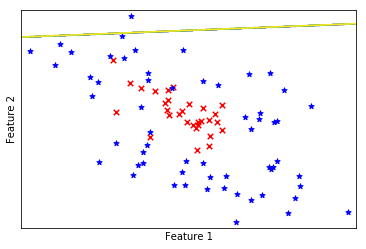

```python
# Plot the decision boundary. For that, we will assign a color to each point in the mesh [x_min, x_max]x[y_min, y_max].
X_train = pd.DataFrame(X_train)
y_train = pd.DataFrame(y_train)
X_train['y_train'] = y_train
new_data = X_train
new_data0 = new_data[new_data['y_train'] == 0]
new_data1 = new_data[new_data['y_train'] == 1]

x_min, x_max = new_data[['feature_1']].min() - .5, new_data[['feature_1']].max() + .5
y_min, y_max = new_data[['feature_2']].min() - .5, new_data[['feature_2']].max() + .5
h = .02  # step size in the mesh
xx, yy = np.meshgrid(np.arange(x_min, x_max, h), np.arange(y_min, y_max, h))
Z = logreg.predict(np.c_[xx.ravel(), yy.ravel()])

# Put the result into a color plot
Z = Z.reshape(xx.shape)
plt.contour(xx, yy, Z)

# Plot also the training points
plt.scatter(new_data1['feature_1'], new_data1['feature_2'], marker = 'x', color = 'r', label = '1', s = 30)
plt.scatter(new_data0['feature_1'], new_data0['feature_2'], marker = '*', color = 'b', label = '0', s = 30)
plt.xlabel('Feature 1')
plt.ylabel('Feature 2')

plt.xlim(xx.min(), xx.max())
plt.ylim(yy.min(), yy.max())
plt.xticks(())
plt.yticks(())

plt.show()
```

Fit the data to a Gaussian naive Bayes model and plot the decision boundary.

```python
from sklearn.naive_bayes import GaussianNB
from sklearn.model_selection import train_test_split
from matplotlib import pyplot as plt
import pandas as pd
import numpy as np
import math
```

```python
X = dataset[['feature_1','feature_2']]
Y = dataset.label

X_train, X_test, y_train, y_test = train_test_split(X, Y, test_size = .1, random_state=np.random.randint(10e5))

#Use a Gaussian naive Bayes model to fit the data
gnb = GaussianNB()
gnb.fit(X_train, y_train)

#Get the predictive value of Y
y_pred = gnb.predict(X_test)

print(classification_report(y_test, y_pred))
```

```
             precision    recall  f1-score   support

        0.0       0.90      0.85      0.87        65
        1.0       0.66      0.76      0.70        25

avg / total       0.83      0.82      0.83        90
```

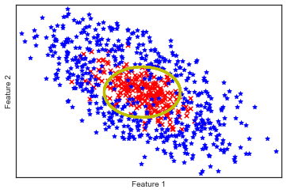

```python
# Plot the decision boundary. For that, we will assign a color to each point in the mesh [x_min, x_max]x[y_min, y_max].
X_train = pd.DataFrame(X_train)
y_train = pd.DataFrame(y_train)
X_train['y_train'] = y_train
new_data = X_train
new_data0 = new_data[new_data['y_train'] == 0]
new_data1 = new_data[new_data['y_train'] == 1]

x_min, x_max = new_data[['feature_1']].min() - .5, new_data[['feature_1']].max() + .5
y_min, y_max = new_data[['feature_2']].min() - .5, new_data[['feature_2']].max() + .5
h = .02  # step size in the mesh
xx, yy = np.meshgrid(np.arange(x_min, x_max, h), np.arange(y_min, y_max, h))
Z = gnb.predict(np.c_[xx.ravel(), yy.ravel()])

# Put the result into a color plot
Z = Z.reshape(xx.shape)
plt.contour(xx, yy, Z,colors='y', linewidths=3)

# Plot also the training points
plt.scatter(new_data1['feature_1'], new_data1['feature_2'], marker = 'x', color = 'r', label = '1', s = 30)
plt.scatter(new_data0['feature_1'], new_data0['feature_2'], marker = '*', color = 'b', label = '0', s = 30)
plt.xlabel('Feature 1')
plt.ylabel('Feature 2')

plt.xlim(xx.min(), xx.max())
plt.ylim(yy.min(), yy.max())
plt.xticks(())
plt.yticks(())

plt.show()
```

Compare these two results, the Gaussian naive Bayes classifier yields a better result than the logistic regression classifier.

## (c)

```python
# input data
data = pd.read_csv("dataset_1.csv")
dataset = pd.DataFrame(data)

# rename the columns of dataset
dataset.columns = ['feature_1', 'feature_2','label']

# augment the dataset with three new features
dataset['feature_3'] = dataset['feature_1'].map(lambda x: x**2)
dataset['feature_4'] =dataset['feature_1']*dataset['feature_2']
dataset['feature_5'] = dataset['feature_2'].map(lambda x: x**2)

dataset.head
```

[output not shown]

[output cut: 49 more lines]

## (d)

```python
X = dataset[['feature_1','feature_2', 'feature_3', 'feature_4', 'feature_5']]
Y = dataset.label

X_train, X_test, y_train, y_test = train_test_split(X, Y, test_size = .1, random_state=np.random.randint(10e5))

# Use Logistic Regression model and fit the data
logreg = LogisticRegression(solver='lbfgs', multi_class='multinomial')
logreg.fit(X_train, y_train)

#Get the predictive value of Y
y_pred = logreg.predict(X_test)

print(classification_report(y_test, y_pred))
```

```
             precision    recall  f1-score   support

        0.0       0.96      0.87      0.91        60
        1.0       0.78      0.93      0.85        30

avg / total       0.90      0.89      0.89        90
```

```python
X = dataset[['feature_1','feature_2', 'feature_3', 'feature_4', 'feature_5']]
Y = dataset.label

X_train, X_test, y_train, y_test = train_test_split(X, Y, test_size = .1, random_state=np.random.randint(10e5))

#Use a Gaussian naive Bayes model to fit the data
gnb = GaussianNB()
gnb.fit(X_train, y_train)

#Get the predictive value of Y
y_pred = gnb.predict(X_test)

print(classification_report(y_test, y_pred))
```

```
             precision    recall  f1-score   support

        0.0       1.00      0.74      0.85        62
        1.0       0.64      1.00      0.78        28

avg / total       0.89      0.82      0.83        90
```

## (e)

Plot the plane curve:  
$y = c_{0}+c_{1}x_{1}+c_{2}x_{2}+c_{3}x_{1}^{2}+c_{4}x_{1}x_{2}+c_{5}x_{2}^{2}$

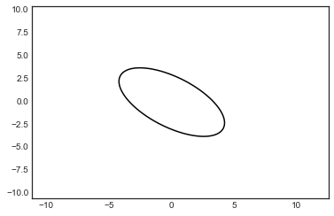

```python
from matplotlib import pyplot as plt
plt.style.use('seaborn-white')

X = dataset[['feature_1','feature_2', 'feature_3', 'feature_4', 'feature_5']]
Y = dataset.label

X_train, X_test, y_train, y_test = train_test_split(X, Y, test_size = .1, random_state=np.random.randint(10e5))

logreg = LogisticRegression(solver='lbfgs', multi_class='multinomial')
logreg.fit(X_train, y_train)
w2 = logreg.coef_
w1 = logreg.intercept_
w = np.append(w1, w2)

x_min, x_max = X_train[['feature_1']].min() - .5, X_train[['feature_1']].max() + .5
y_min, y_max = X_train[['feature_2']].min() - .5, X_train[['feature_2']].max() + .5
h = .02  # step size in the mesh
xx, yy = np.meshgrid(np.arange(x_min, x_max, h), np.arange(y_min, y_max, h))


def f(x1, x2, w):
    return w[0] + w[1]*x1 + w[2]*x2 + w[3]*x1**2 + w[4]*x1*x2 + w[5]*x2**2

zz = f(xx, yy, w)
plt.contour(xx, yy, zz,levels=[0],colors='black')
```

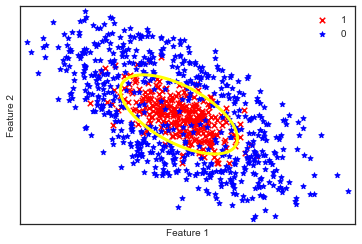

```python
from sklearn.linear_model import LogisticRegression
from sklearn.model_selection import train_test_split
from sklearn.metrics import confusion_matrix
from sklearn.metrics import classification_report
from matplotlib import pyplot as plt
import pandas as pd
import numpy as np

# input data
data = pd.read_csv("dataset_1.csv")
dataset = pd.DataFrame(data)

# rename the columns of dataset
dataset.columns = ['feature_1', 'feature_2','label']

# augment the dataset with three new features
dataset['feature_3'] = dataset['feature_1'].map(lambda x: x**2)
dataset['feature_4'] =dataset['feature_1']*dataset['feature_2']
dataset['feature_5'] = dataset['feature_2'].map(lambda x: x**2)

#select subdataset by label 0 or 1
data1 = dataset[dataset['label'] == 1]
data0 = dataset[dataset['label'] == 0]

#scatter plot
p1 = plt.scatter(data1['feature_1'], data1['feature_2'], marker = 'x', color = 'r', label = '1', s = 30)
p2 = plt.scatter(data0['feature_1'], data0['feature_2'], marker = '*', color = 'b', label = '0', s = 30)
plt.legend(loc = 'upper right')

#plot decision boundary
X = dataset[['feature_1','feature_2', 'feature_3', 'feature_4', 'feature_5']]
Y = dataset.label

X_train, X_test, y_train, y_test = train_test_split(X, Y, test_size = .1, random_state=np.random.randint(10e5))

logreg = LogisticRegression(solver='lbfgs', multi_class='multinomial')
logreg.fit(X_train, y_train)
w2 = logreg.coef_
w1 = logreg.intercept_
w = np.append(w1, w2)

x_min, x_max = X_train[['feature_1']].min() - .5, X_train[['feature_1']].max() + .5
y_min, y_max = X_train[['feature_2']].min() - .5, X_train[['feature_2']].max() + .5
h = .02  # step size in the mesh
xx, yy = np.meshgrid(np.arange(x_min, x_max, h), np.arange(y_min, y_max, h))


def f(x1, x2, w):
    return w[0] + w[1]*x1 + w[2]*x2 + w[3]*x1**2 + w[4]*x1*x2 + w[5]*x2**2

zz = f(xx, yy, w)
plt.contour(xx, yy, zz,levels=[0],colors='yellow',linewidths = 3)

plt.xlabel('Feature 1')
plt.ylabel('Feature 2')
plt.xticks(())
plt.yticks(())
plt.show()
```

Plot decision boundary

## (f)

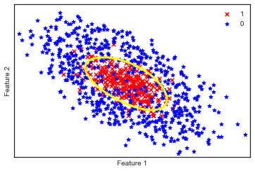

```python
from sklearn.linear_model import LogisticRegression
from sklearn.model_selection import train_test_split
from sklearn.metrics import confusion_matrix
from sklearn.metrics import classification_report
from matplotlib import pyplot as plt
import pandas as pd
import numpy as np

# input data
data = pd.read_csv("dataset_1.csv")
dataset = pd.DataFrame(data)

# rename the columns of dataset
dataset.columns = ['feature_1', 'feature_2','label']

# augment the dataset with new features
dataset['feature_3'] = dataset['feature_1'].map(lambda x: x**2)
dataset['feature_4'] =dataset['feature_1']*dataset['feature_2']
dataset['feature_5'] = dataset['feature_2'].map(lambda x: x**2)
dataset['feature_6'] = dataset['feature_1'].map(lambda x: x**3)
dataset['feature_7'] = dataset['feature_3']*dataset['feature_2']
dataset['feature_8'] = dataset['feature_5']*dataset['feature_1']
dataset['feature_9'] = dataset['feature_2'].map(lambda x: x**3)
dataset['feature_10'] = dataset['feature_3']*dataset['feature_2']
dataset['feature_11'] = dataset['feature_5']*dataset['feature_1']

#select subdataset by label 0 or 1
data1 = dataset[dataset['label'] == 1]
data0 = dataset[dataset['label'] == 0]

#scatter plot
p1 = plt.scatter(data1['feature_1'], data1['feature_2'], marker = 'x', color = 'r', label = '1', s = 30)
p2 = plt.scatter(data0['feature_1'], data0['feature_2'], marker = '*', color = 'b', label = '0', s = 30)
plt.legend(loc = 'upper right')

#plot decision boundary
X = dataset[['feature_1','feature_2','feature_3', 'feature_4', 'feature_5','feature_6','feature_7','feature_8','feature_9',
             'feature_10','feature_11']]
Y = dataset.label

X_train, X_test, y_train, y_test = train_test_split(X, Y, test_size = .1, random_state=np.random.randint(10e5))

logreg = LogisticRegression(solver='lbfgs', multi_class='multinomial')
logreg.fit(X_train, y_train)
w2 = logreg.coef_
w1 = logreg.intercept_
w = np.append(w1, w2)

x_min, x_max = X_train[['feature_1']].min() - .5, X_train[['feature_1']].max() + .5
y_min, y_max = X_train[['feature_2']].min() - .5, X_train[['feature_2']].max() + .5
h = .02  # step size in the mesh
xx, yy = np.meshgrid(np.arange(x_min, x_max, h), np.arange(y_min, y_max, h))

def f(x1, x2, w):
    return w[0] + w[1]*x1 + w[2]*x2 + w[3]*x1**2 + w[4]*x1*x2 + w[5]*x2**2 + w[6]*x1**3 +w[7]*x1**2*x2 + w[8]*x2**2*x1 + w[9]*x2**3 + w[10]*x2*x1**2 + w[11]*x1*x2**2

plt.contour(xx, yy, f(xx, yy, w),0, colors='yellow',linewidths = 3)
plt.xlabel('Feature 1')
plt.ylabel('Feature 2')
plt.xticks(())
plt.yticks(())
plt.show()
```

It seems very similar to the figure in (e). Therefore, to save computational time, using the model in (e) with degree 2 is sufficient.

# Problem 5

## (a)

```python
from sklearn.linear_model import LogisticRegression
from sklearn.model_selection import train_test_split
from sklearn.metrics import confusion_matrix
from sklearn.metrics import classification_report
from matplotlib import pyplot as plt
import pandas as pd
import numpy as np
```

[output not shown]

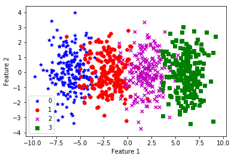

```python
# input data
data = pd.read_csv("dataset_3.csv")
dataset = pd.DataFrame(data)

# rename the columns of dataset
dataset.columns = ['feature_1', 'feature_2','label']

#select subdataset by label 0, 1, 2, 3
data0 = dataset[dataset['label'] == 0]
data1 = dataset[dataset['label'] == 1]
data2 = dataset[dataset['label'] == 2]
data3 = dataset[dataset['label'] == 3]

#scatter plot
p0 = plt.scatter(data0['feature_1'], data0['feature_2'], marker = '*', color = 'b', label = '0', s = 30)
p1 = plt.scatter(data1['feature_1'], data1['feature_2'], marker = 'o', color = 'r', label = '1', s = 30)
p2 = plt.scatter(data2['feature_1'], data2['feature_2'], marker = 'x', color = 'm', label = '2', s = 30)
p3 = plt.scatter(data3['feature_1'], data3['feature_2'], marker = 's', color = 'g', label = '3', s = 30)
plt.legend(loc = 'lower left')
plt.xlabel('Feature 1')
plt.ylabel('Feature 2')
```

## (b)

```python
X = dataset[['feature_1','feature_2']]
Y = pd.DataFrame(dataset.label)

np.random.seed(20190313)

X_train, X_test, y_train, y_test = train_test_split(X, Y, test_size = .25, random_state=np.random.randint(10e5))

y_tr = y_train
y_te = y_test
```

## (c)

```python
# construct new training target vectors, making it binary
y_tr0 = y_tr.replace({1:4, 2:4, 3:4})
y_tr1 = y_tr.replace({0:4, 2:4, 3:4})
y_tr2 = y_tr.replace({0:4, 1:4, 3:4})
y_tr3 = y_tr.replace({0:4, 1:4, 2:4})

# construct new testing target vectors, making it binary
y_te0 = y_te.replace({1:4, 2:4, 3:4})
y_te1 = y_te.replace({0:4, 2:4, 3:4})
y_te2 = y_te.replace({0:4, 1:4, 3:4})
y_te3 = y_te.replace({0:4, 1:4, 2:4})

# fit the training data with logistic regression model
#y_tr0_new = column_or_1d(y_tr0, warn=True)
logreg0 = LogisticRegression(solver='lbfgs', multi_class='multinomial')
logreg0.fit(X_train, y_tr0.values.ravel())

logreg1 = LogisticRegression(solver='lbfgs', multi_class='multinomial')
logreg1.fit(X_train, y_tr1.values.ravel())

logreg2 = LogisticRegression(solver='lbfgs', multi_class='multinomial')
logreg2.fit(X_train, y_tr2.values.ravel())

logreg3 = LogisticRegression(solver='lbfgs', multi_class='multinomial')
logreg3.fit(X_train, y_tr3.values.ravel())
```

```
LogisticRegression(C=1.0, class_weight=None, dual=False, fit_intercept=True,
          intercept_scaling=1, max_iter=100, multi_class='multinomial',
          n_jobs=1, penalty='l2', random_state=None, solver='lbfgs',
          tol=0.0001, verbose=0, warm_start=False)
```

## (d)

```python
# Use score method to get accuracy of model
score0 = logreg0.score(X_test, y_te0)
score1 = logreg1.score(X_test, y_te1)
score2 = logreg2.score(X_test, y_te2)
score3 = logreg3.score(X_test, y_te3)

avg_score = (score0 + score1 + score2 + score3) / 4
print(score0, score1, score2, score3)
print(avg_score)
```

```
0.97 0.75 0.72 0.99
0.8574999999999999
```

## (e)

```
             precision    recall  f1-score   support

        0.0       0.89      1.00      0.94        17
        1.0       1.00      0.84      0.91        25
        2.0       0.81      1.00      0.89        17
        3.0       1.00      0.90      0.95        21

avg / total       0.94      0.93      0.93        80
```

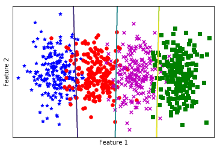

```python
from sklearn.linear_model import LogisticRegression
from sklearn.model_selection import train_test_split
from sklearn.metrics import confusion_matrix
from sklearn.metrics import classification_report
from matplotlib import pyplot as plt
import pandas as pd
import numpy as np

# input data
data = pd.read_csv("dataset_3.csv")
dataset = pd.DataFrame(data)

# rename the columns of dataset
dataset.columns = ['feature_1', 'feature_2','label']

#select subdataset by label 0 or 1
data0 = dataset[dataset['label'] == 0]
data1 = dataset[dataset['label'] == 1]
data2 = dataset[dataset['label'] == 2]
data3 = dataset[dataset['label'] == 3]

X = dataset[['feature_1','feature_2']]
Y = dataset.label

X_train, X_test, y_train, y_test = train_test_split(X, Y, test_size = .1, random_state=np.random.randint(10e5))

# Use Logistic Regression model and fit the data
logreg = LogisticRegression(solver='lbfgs', multi_class='multinomial')
logreg.fit(X_train, y_train)

#Get the predictive value of Y
y_pred = logreg.predict(X_test)

print(classification_report(y_test, y_pred))

# Plot the decision boundary. For that, we will assign a color to each point in the mesh [x_min, x_max]x[y_min, y_max].
X_train = pd.DataFrame(X_train)
y_train = pd.DataFrame(y_train)
X_train['y_train'] = y_train
new_data = X_train
new_data0 = new_data[new_data['y_train'] == 0]
new_data1 = new_data[new_data['y_train'] == 1]
new_data2 = new_data[new_data['y_train'] == 2]
new_data3 = new_data[new_data['y_train'] == 3]

x_min, x_max = new_data[['feature_1']].min() - .5, new_data[['feature_1']].max() + .5
y_min, y_max = new_data[['feature_2']].min() - .5, new_data[['feature_2']].max() + .5
h = .02  # step size in the mesh
x_min = np.asarray(x_min)
x_max = np.asarray(x_max)
y_min = np.asarray(y_min)
y_max = np.asarray(y_max)
xx, yy = np.meshgrid(np.arange(x_min, x_max, h), np.arange(y_min, y_max, h))
Z = logreg.predict(np.c_[xx.ravel(), yy.ravel()])

# Put the result into a color plot
Z = Z.reshape(xx.shape)
plt.contour(xx, yy, Z)

# Plot also the training points
p0 = plt.scatter(data0['feature_1'], data0['feature_2'], marker = '*', color = 'b', label = '0', s = 30)
p1 = plt.scatter(data1['feature_1'], data1['feature_2'], marker = 'o', color = 'r', label = '1', s = 30)
p2 = plt.scatter(data2['feature_1'], data2['feature_2'], marker = 'x', color = 'm', label = '2', s = 30)
p3 = plt.scatter(data3['feature_1'], data3['feature_2'], marker = 's', color = 'g', label = '3', s = 30)
plt.xlabel('Feature 1')
plt.ylabel('Feature 2')

plt.xlim(xx.min(), xx.max())
plt.ylim(yy.min(), yy.max())
plt.xticks(())
plt.yticks(())

plt.show()
```